# DADA2 - KelleyMicrobiome ITS2 Plate 3 & 4

```r
# if (!require("BiocManager", quietly = TRUE))
#     install.packages("BiocManager")
#
#BiocManager::install("phyloseq")
```

```r
ncores = 24
```

```r
library(tidyverse)
library(dada2)
library(ShortRead)
library(Biostrings)
library(phyloseq)
```

```r
seqDIR = '/project/mmicrobe/Kelley/ITS2/Raw/KY21-3-4/raw'
path = seqDIR
list.files(path)
```

```
  [1] "1_1_4_S-Plate4A9_S82_L001_R1_001.fastq.gz"
  [2] "1_1_4_S-Plate4A9_S82_L001_R2_001.fastq.gz"
  [3] "1_2_4_S-Plate3E1_S5_L001_R1_001.fastq.gz"
  [4] "1_2_4_S-Plate3E1_S5_L001_R2_001.fastq.gz"
  [5] "1_x_1__Rh-Plate6B8_S55_L001_R1_001.fastq.gz"
  [6] "1_x_1__Rh-Plate6B8_S55_L001_R2_001.fastq.gz"
  [7] "1_x_1_R-Plate4A1_S74_L001_R1_001.fastq.gz"
  [8] "1_x_1_R-Plate4A1_S74_L001_R2_001.fastq.gz"
  [9] "1_x_1_Rh-Plate3A7_S49_L001_R1_001.fastq.gz"
 [10] "1_x_1_Rh-Plate3A7_S49_L001_R2_001.fastq.gz"
 [11] "1_x_2_R-Plate4B1_S85_L001_R1_001.fastq.gz"
 [12] "1_x_2_R-Plate4B1_S85_L001_R2_001.fastq.gz"
 [13] "1_x_2_Rh-Plate3C3_S19_L001_R1_001.fastq.gz"
 [14] "1_x_2_Rh-Plate3C3_S19_L001_R2_001.fastq.gz"
 [15] "1_x_3_R-Plate4C1_S95_L001_R1_001.fastq.gz"
```

[output cut: 299 more lines]

# Collect files

```r
#Collect forward and reverse names in order
fnFs <- sort(list.files(path, pattern = "_R1_001.fastq.gz", full.names = TRUE))
fnRs <- sort(list.files(path, pattern = "_R2_001.fastq.gz", full.names = TRUE))
if(length(fnFs) != length(fnRs)) stop("Forward and reverse files do not match.")
```

# Identify primers

```r
FWD <- "AACTTTYRRCAAYGGATCWCT"  ## ITS2 5.8S forward primer sequence
REV <- "AGCCTCCGCTTATTGATATGCTTAART"  ## ITS2 ITS4Fun primer sequence
FSEQ = "TCTTTCCCTACACGACGCTCTTCCGATCT" # Forward sequencing primer
RSEQ = "GTGACTGGAGTTCAGACGTGTGCTCTTCCGATCT" # Reverse sequencing primer
```

```r
allOrients <- function(primer) {
    # Create all orientations of the input sequence
    require(Biostrings)
    dna <- DNAString(primer)  # The Biostrings works w/ DNAString objects rather than character vectors
    orients <- c(Forward = dna, Complement = Biostrings::complement(dna), Reverse = Biostrings::reverse(dna),
        RevComp = Biostrings::reverseComplement(dna))
    return(sapply(orients, toString))  # Convert back to character vector
}
FWD.orients <- allOrients(FWD)
REV.orients <- allOrients(REV)
FSEQ.orients <- allOrients(FSEQ)
RSEQ.orients <- allOrients(RSEQ)
FWD.orients
```

```
                Forward              Complement                 Reverse
"AACTTTYRRCAAYGGATCWCT" "TTGAAARYYGTTRCCTAGWGA" "TCWCTAGGYAACRRYTTTCAA"
                RevComp
"AGWGATCCRTTGYYRAAAGTT"
```

```r
REV.orients
```

```
                      Forward                    Complement
"AGCCTCCGCTTATTGATATGCTTAART" "TCGGAGGCGAATAACTATACGAATTYA"
                      Reverse                       RevComp
"TRAATTCGTATAGTTATTCGCCTCCGA" "AYTTAAGCATATCAATAAGCGGAGGCT"
```

```r
FSEQ.orients
```

```
                        Forward                      Complement
"TCTTTCCCTACACGACGCTCTTCCGATCT" "AGAAAGGGATGTGCTGCGAGAAGGCTAGA"
                        Reverse                         RevComp
"TCTAGCCTTCTCGCAGCACATCCCTTTCT" "AGATCGGAAGAGCGTCGTGTAGGGAAAGA"
```

```r
RSEQ.orients
```

```
                             Forward                           Complement
"GTGACTGGAGTTCAGACGTGTGCTCTTCCGATCT" "CACTGACCTCAAGTCTGCACACGAGAAGGCTAGA"
                             Reverse                              RevComp
"TCTAGCCTTCTCGTGTGCAGACTTGAGGTCAGTG" "AGATCGGAAGAGCACACGTCTGAACTCCAGTCAC"
```

```r
if (file.exists(file.path(path, "filtN"))){
  print(TRUE)
} else {
  #create new subdirectory
  dir.create(file.path(path,"filtN"))
}
```

```r
fnFs.filtN <- file.path(path, "filtN", basename(fnFs)) # Put N-filtered files in filtN/ subdirectory
fnRs.filtN <- file.path(path, "filtN", basename(fnRs))
filterAndTrim(fnFs, fnFs.filtN, fnRs, fnRs.filtN, maxN = 0, multithread = ncores)

fnFs.filtN[1]
```

```
[1] "/project/mmicrobe/Kelley/ITS2/Raw/KY21-3-4/raw/filtN/1_1_4_S-Plate4A9_S82_L001_R1_001.fastq.gz"
```

```r
fnRs.filtN[1]
```

```
[1] "/project/mmicrobe/Kelley/ITS2/Raw/KY21-3-4/raw/filtN/1_1_4_S-Plate4A9_S82_L001_R2_001.fastq.gz"
```

## Check orientation and read through

```r
primerHits <- function(primer, fn) {
    # Counts number of reads in which the primer is found
    nhits <- vcountPattern(primer, sread(readFastq(fn)), fixed = FALSE)
    return(sum(nhits > 0))
}
rbind(
  FWD.ForwardReads = sapply(FWD.orients, primerHits, fn = fnFs.filtN[[7]]),
  FWD.ReverseReads = sapply(FWD.orients,
    primerHits, fn = fnRs.filtN[[7]]),
  REV.ForwardReads = sapply(REV.orients, primerHits,
    fn = fnFs.filtN[[7]]),
  REV.ReverseReads = sapply(REV.orients, primerHits, fn = fnRs.filtN[[7]]))
```

```
                 Forward Complement Reverse RevComp
FWD.ForwardReads   52001          0       0       0
FWD.ReverseReads       0          0       0     621
REV.ForwardReads       0          0       0     325
REV.ReverseReads   44240          0       0       0
```

Some primer read through

Check for the sequencing adapters to see if there are similar counts

```r
rbind(
  FSEQ.ForwardReads = sapply(FSEQ.orients, primerHits, fn = fnFs.filtN[[7]]),
  FSEQ.ReverseReads = sapply(FSEQ.orients,
    primerHits, fn = fnRs.filtN[[7]]),
  RSEQ.ForwardReads = sapply(RSEQ.orients, primerHits,
    fn = fnFs.filtN[[7]]),
  RSEQ.ReverseReads = sapply(RSEQ.orients, primerHits, fn = fnRs.filtN[[7]]))
```

```
                  Forward Complement Reverse RevComp
FSEQ.ForwardReads       0          0       0       0
FSEQ.ReverseReads       0          0       0     694
RSEQ.ForwardReads       0          0       0     699
RSEQ.ReverseReads       0          0       0       0
```

Some sequencing primers present

# Execute cutadapt from bash script through ssh

The system command was not working properly, so used R to generate adapter and RC sequences and ran bash_cutadapt.sh script. Note to run using sbatch in order to run job on compute node.

```r
# cutadapt <- "/home/bryan.emmett/.local/bin/cutadapt"
# system2(command = cutadapt, args = "--version")
```

### Create directory for trimmed sequences

```r
path.cut <- file.path(path, "cutadapt")
if(!dir.exists(path.cut)) dir.create(path.cut)
fnFs.cut <- file.path(path.cut, basename(fnFs))
fnRs.cut <- file.path(path.cut, basename(fnRs))
```

### Define primers

```r
FWD.RC <- dada2:::rc(FWD)
REV.RC <- dada2:::rc(REV)
FWD
```

```
[1] "AACTTTYRRCAAYGGATCWCT"
```

```r
REV
```

```
[1] "AGCCTCCGCTTATTGATATGCTTAART"
```

```r
FWD.RC
```

```
[1] "AGWGATCCRTTGYYRAAAGTT"
```

```r
REV.RC
```

```
[1] "AYTTAAGCATATCAATAAGCGGAGGCT"
```

```r
R1.flags <- paste("-g", FWD, "-a", REV.RC)
R2.flags <- paste("-G", REV, "-A", FWD.RC)
R1.flags
```

```
[1] "-g AACTTTYRRCAAYGGATCWCT -a AYTTAAGCATATCAATAAGCGGAGGCT"
```

```r
R2.flags
```

```
[1] "-G AGCCTCCGCTTATTGATATGCTTAART -A AGWGATCCRTTGYYRAAAGTT"
```

```r
fnRs.cut[1]
```

```
[1] "/project/mmicrobe/Kelley/ITS2/Raw/KY21-3-4/raw/cutadapt/1_1_4_S-Plate4A9_S82_L001_R2_001.fastq.gz"
```

# Resume here when first cutadapt job is finished

## Check cut adapt

```r
rbind(FWD.ForwardReads = sapply(FWD.orients, primerHits, fn = fnFs.cut[[1]]), FWD.ReverseReads = sapply(FWD.orients,
    primerHits, fn = fnRs.cut[[1]]), REV.ForwardReads = sapply(REV.orients, primerHits,
    fn = fnFs.cut[[1]]), REV.ReverseReads = sapply(REV.orients, primerHits, fn = fnRs.cut[[1]]))
```

```
                 Forward Complement Reverse RevComp
FWD.ForwardReads       0          0       0       0
FWD.ReverseReads       0          0       0       0
REV.ForwardReads       0          0       0       0
REV.ReverseReads       0          0       0       0
```

Check for the sequencing adapters to see if there are similar counts

```r
rbind(
  FSEQ.ForwardReads = sapply(FSEQ.orients, primerHits, fn = fnFs.cut[[1]]),
  FSEQ.ReverseReads = sapply(FSEQ.orients,
    primerHits, fn = fnRs.cut[[1]]),
  RSEQ.ForwardReads = sapply(RSEQ.orients, primerHits,
    fn = fnFs.cut[[1]]),
  RSEQ.ReverseReads = sapply(RSEQ.orients, primerHits, fn = fnRs.cut[[1]]))
```

```
                  Forward Complement Reverse RevComp
FSEQ.ForwardReads       0          0       0       0
FSEQ.ReverseReads       0          0       0      86
RSEQ.ForwardReads       0          0       0       5
RSEQ.ReverseReads       0          0       0       0
```

Some sequences remain with sequencing primers. Need to re-run cut-adapt and include adapter sequences and filter for fragments smaller than a certain size.

## Check after second cutadapt round

changing path to cut files to target new cutadapt2 folder

```r
path.cut2 <- file.path(path, "cutadapt2")
#if(!dir.exists(path.cut)) dir.create(path.cut)
fnFs.cut <- file.path(path.cut2, basename(fnFs))
fnRs.cut <- file.path(path.cut2, basename(fnRs))
```

```r
fnFs.cut[1]
```

[output not shown]

```r
rbind(
  FSEQ.ForwardReads = sapply(FSEQ.orients, primerHits, fn = fnFs.cut[[1]]),
  FSEQ.ReverseReads = sapply(FSEQ.orients,
    primerHits, fn = fnRs.cut[[1]]),
  RSEQ.ForwardReads = sapply(RSEQ.orients, primerHits,
    fn = fnFs.cut[[1]]),
  RSEQ.ReverseReads = sapply(RSEQ.orients, primerHits, fn = fnRs.cut[[1]]))
```

```
                  Forward Complement Reverse RevComp
FSEQ.ForwardReads       0          0       0       0
FSEQ.ReverseReads       0          0       0       0
RSEQ.ForwardReads       0          0       0       0
RSEQ.ReverseReads       0          0       0       0
```

```r
# Forward and reverse fastq filenames have the format:
cutFs <- sort(list.files(path.cut2, pattern = "_R1_001.fastq.gz", full.names = TRUE))
cutRs <- sort(list.files(path.cut2, pattern = "_R2_001.fastq.gz", full.names = TRUE))

# Extract sample names, assuming filenames have format:
get.sample.name <- function(fname) strsplit(basename(fname), "_S")[[1]][1]
sample.names <- unname(sapply(cutFs, get.sample.name))

sample.names = sample.names[-28]
sample.names
```

```
  [1] "1_1_4"        "1_2_4"        "1_x_1__Rh"    "1_x_1_R"
  [5] "1_x_1_Rh"     "1_x_2_R"      "1_x_2_Rh"     "1_x_3_R"
  [9] "1_x_3_Rh_"    "1_x_3_Rh"     "1_x_4_R"      "11_1_4"
 [13] "11_2_1"       "11_2_2"       "11_2_4"       "11_x_1_R"
 [17] "11_x_1_Rh"    "11_x_2_R"     "11_x_3_R"     "11_x_3_Rh"
 [21] "11_x_4_R"     "13_1_4"       "13_2_1"       "13_2_4"
 [25] "13_x_1_R"     "13_x_2_R"     "13_x_3_R"     "13_x_4_R"
 [29] "14_1_4"       "14_2_4"       "14_2_5"       "14_x_1_R"
 [33] "14_x_1_Rh"    "14_x_2_R"     "14_x_3_R"     "14_x_4_R"
 [37] "15_1_3"       "15_1_4"       "15_2_3"       "15_2_4"
 [41] "15_x_1_R"     "15_x_2_R"     "15_x_3_R"     "15_x_4_R"
 [45] "16_1_4"       "16_1_5"       "16_2_4"       "16_2_5"
 [49] "16_x_1_R"     "16_x_1_Rh"    "16_x_2_R"     "16_x_3_R"
 [53] "16_x_3_Rh"    "16_x_4_R"     "16_x_4_Rh"    "17_1_4"
 [57] "17_2_4"       "17_x_1_R"     "17_x_2_R"     "17_x_3_R"
```

[output cut: 22 more lines]

# Plot quality profiles and forward and reverse reads

## Forward reads

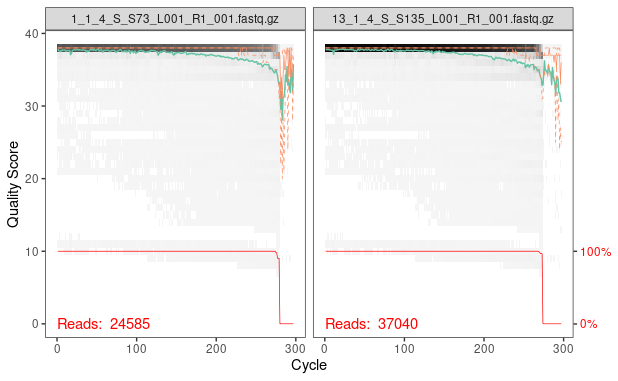

```r
plotQualityProfile(fnFs.cut[c(1,22)])
```

Forward reads are high quality

## Reverse reads

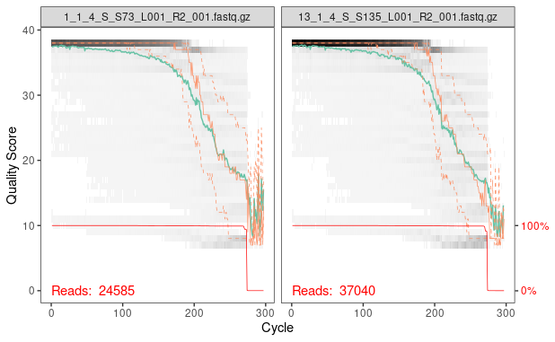

```r
plotQualityProfile(fnRs.cut[c(1,22)])
```

- Reverse reads decrease in quality around 200 bp

## Last check

```r
readLines(fnFs.cut[1], n = 4)
```

```
[1] "@M01479:491:000000000-L7V24:1:1102:21003:1896 1:N:0:TCCGAGGC+TACCGCCT"
[2] "TGGTTCTGGCATCGATGAAGAACGCAGCGAAATGCGATAAGTAATGCGAATTGCAGAATT…"
[3] "+"
[4] "GGGGGGGGGGGGGGGGGGGGGGGGGGGGGGGGGGGGGGGGGGGGGGGGGGGGGGGGGGGG…"
```

```r
readLines(fnRs.cut[1], n = 4)
```

```
[1] "@M01479:491:000000000-L7V24:1:1102:21003:1896 2:N:0:TCCGAGGC+TACCGCCT"
[2] "TCAGCGGGTATCCCTACCTGATCCGAGGTCAACCTTAGAAAGATTCTCCCTGAGGGGAGG…"
[3] "+"
[4] "GGGGGGGGGGGGGGGGGGGGGGGGGGGGGGGGGGGGGGGGGGGGGGGGGGGGGGGGGGGGGGGGGGGGGGGGGGGGGGGGGGGGGGGGFGGGGGGGGGGGGGGGGGGGGGGGGGGGGGGGGGCEGGDGGGGGGGGGFGGEGGEGGF?FDFFGGGGGGGGGGGG5CCGG3DGGGGGGGGGGG4FFFFFFFFFGFEF:A*,4>:F?FFFB?69>(81<>BB;0662:<B>A<(0431931(886()((.8>??F::(()).).2.22(44(4()-"
```

```r
#path
#fastqFs[1]
```

# Filter and trim

```r
filtFs <- file.path(path.cut2, "filtered", basename(cutFs))
filtRs <- file.path(path.cut2, "filtered", basename(cutRs))
```

```r
out <- filterAndTrim(cutFs, filtFs, cutRs, filtRs, maxN = 0, maxEE = c(2, 2), truncQ = 8,
    minLen = 50, rm.phix = TRUE, compress = TRUE, multithread = ncores)  # on windows, set multithread = FALSE
```

```
Creating output directory: /project/mmicrobe/Kelley/ITS2/Raw/KY21-3-4/cutadapt2/filtered
Some input samples had no reads pass the filter.
```

```r
head(out)
```

```
                                   reads.in
1_1_4_S_S73_L001_R1_001.fastq.gz      24585
1_2_4_S_S5_L001_R1_001.fastq.gz       26089
1_x_1__Rh_S55_L001_R1_001.fastq.gz    45816
1_x_1_R_S65_L001_R1_001.fastq.gz      43393
1_x_1_Rh_S49_L001_R1_001.fastq.gz     20781
1_x_2_R_S76_L001_R1_001.fastq.gz      48019
                                   reads.out
1_1_4_S_S73_L001_R1_001.fastq.gz       23011
1_2_4_S_S5_L001_R1_001.fastq.gz        24589
1_x_1__Rh_S55_L001_R1_001.fastq.gz     43117
1_x_1_R_S65_L001_R1_001.fastq.gz       41167
1_x_1_Rh_S49_L001_R1_001.fastq.gz      19788
1_x_2_R_S76_L001_R1_001.fastq.gz       45812
```

```r
head(out)
```

```
                                   reads.in
1_1_4_S_S73_L001_R1_001.fastq.gz      24585
1_2_4_S_S5_L001_R1_001.fastq.gz       26089
1_x_1__Rh_S55_L001_R1_001.fastq.gz    45816
1_x_1_R_S65_L001_R1_001.fastq.gz      43393
1_x_1_Rh_S49_L001_R1_001.fastq.gz     20781
1_x_2_R_S76_L001_R1_001.fastq.gz      48019
                                   reads.out
1_1_4_S_S73_L001_R1_001.fastq.gz       23011
1_2_4_S_S5_L001_R1_001.fastq.gz        24589
1_x_1__Rh_S55_L001_R1_001.fastq.gz     43117
1_x_1_R_S65_L001_R1_001.fastq.gz       41167
1_x_1_Rh_S49_L001_R1_001.fastq.gz      19788
1_x_2_R_S76_L001_R1_001.fastq.gz       45812
```

```r
OutFolder = "/project/mmicrobe/Kelley/ITS2/KY21-3-4"
saveRDS(out, file.path(OutFolder,'FilterTrim.rds'))
```

# Learn errors

```r
set.seed(100)
# Learn forward error rates
errF <- learnErrors(filtFs, multithread = ncores)
```

```
100814949 total bases in 364361 reads from 9 samples will be used for learning the error rates.
```

```r
# Learn reverse error rates
errR <- learnErrors(filtRs, multithread=ncores)
```

```
100808275 total bases in 476528 reads from 12 samples will be used for learning the error rates.
```

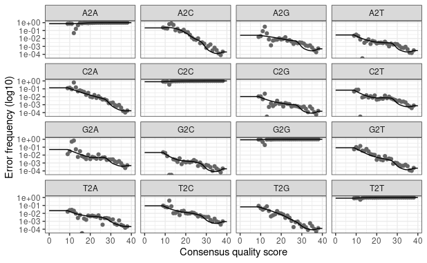

```r
plotErrors(errF)
```

```r
errF_File = file.path(OutFolder,"errF.rds")
saveRDS(errF, errF_File)

errR_File = file.path(OutFolder,"errR.rds")
saveRDS(errR, errR_File)
```

# Sequence Inference

There is a sample with no sequences, C11 on plate three, which needs to be re-amplified. Removing file from list to avoid errors

```r
filtFs = filtFs[-28]
filtRs = filtRs[-28]
```

```r
dadaFs <- dada(filtFs, err = errF, multithread = TRUE)
```

```
Sample 1 - 23011 reads in 4115 unique sequences.
Sample 2 - 24589 reads in 3577 unique sequences.
Sample 3 - 43117 reads in 5768 unique sequences.
Sample 4 - 41167 reads in 4414 unique sequences.
Sample 5 - 19788 reads in 2928 unique sequences.
Sample 6 - 45812 reads in 5226 unique sequences.
Sample 7 - 49430 reads in 6659 unique sequences.
Sample 8 - 55352 reads in 8212 unique sequences.
Sample 9 - 62095 reads in 9413 unique sequences.
Sample 10 - 32734 reads in 4315 unique sequences.
Sample 11 - 39387 reads in 5237 unique sequences.
Sample 12 - 40046 reads in 8119 unique sequences.
Sample 13 - 41633 reads in 6435 unique sequences.
Sample 14 - 63672 reads in 9031 unique sequences.
Sample 15 - 52560 reads in 7631 unique sequences.
Sample 16 - 59312 reads in 6040 unique sequences.
Sample 17 - 131075 reads in 24435 unique sequences.
Sample 18 - 46525 reads in 5659 unique sequences.
Sample 19 - 73577 reads in 9168 unique sequences.
Sample 20 - 68889 reads in 13280 unique sequences.
Sample 21 - 78039 reads in 8050 unique sequences.
Sample 22 - 34856 reads in 6715 unique sequences.
Sample 23 - 31509 reads in 4542 unique sequences.
Sample 24 - 37743 reads in 5408 unique sequences.
Sample 25 - 46504 reads in 3378 unique sequences.
Sample 26 - 45019 reads in 4063 unique sequences.
Sample 27 - 48668 reads in 6885 unique sequences.
Sample 28 - 59515 reads in 8173 unique sequences.
Sample 29 - 39186 reads in 6327 unique sequences.
Sample 30 - 36609 reads in 5576 unique sequences.
Sample 31 - 26654 reads in 4250 unique sequences.
Sample 32 - 57188 reads in 5166 unique sequences.
Sample 33 - 39817 reads in 6104 unique sequences.
Sample 34 - 57337 reads in 5727 unique sequences.
Sample 35 - 70986 reads in 8938 unique sequences.
Sample 36 - 83936 reads in 11047 unique sequences.
Sample 37 - 84420 reads in 12496 unique sequences.
Sample 38 - 44199 reads in 7418 unique sequences.
Sample 39 - 40849 reads in 6155 unique sequences.
Sample 40 - 43695 reads in 5624 unique sequences.
Sample 41 - 49767 reads in 4177 unique sequences.
Sample 42 - 64263 reads in 7294 unique sequences.
Sample 43 - 61847 reads in 7708 unique sequences.
Sample 44 - 60911 reads in 8996 unique sequences.
Sample 45 - 35909 reads in 6685 unique sequences.
Sample 46 - 60077 reads in 7017 unique sequences.
Sample 47 - 23649 reads in 3546 unique sequences.
Sample 48 - 45961 reads in 5753 unique sequences.
Sample 49 - 57801 reads in 4094 unique sequences.
Sample 50 - 86551 reads in 13223 unique sequences.
Sample 51 - 58089 reads in 5429 unique sequences.
Sample 52 - 70866 reads in 8717 unique sequences.
Sample 53 - 77396 reads in 11536 unique sequences.
Sample 54 - 82515 reads in 7731 unique sequences.
Sample 55 - 68222 reads in 11383 unique sequences.
Sample 56 - 38525 reads in 6442 unique sequences.
```

# Merge paired end reads

```r
mergers <- mergePairs(dadaFs, filtFs, dadaRs, filtRs, verbose=TRUE)
```

```
19956 paired-reads (in 208 unique pairings) successfully merged out of 22074 (in 330 pairings) input.
22275 paired-reads (in 183 unique pairings) successfully merged out of 24184 (in 252 pairings) input.
Duplicate sequences in merged output.
39494 paired-reads (in 252 unique pairings) successfully merged out of 42343 (in 397 pairings) input.
Duplicate sequences in merged output.
39935 paired-reads (in 83 unique pairings) successfully merged out of 40701 (in 137 pairings) input.
17582 paired-reads (in 125 unique pairings) successfully merged out of 19007 (in 189 pairings) input.
44523 paired-reads (in 127 unique pairings) successfully merged out of 45328 (in 202 pairings) input.
Duplicate sequences in merged output.
46739 paired-reads (in 182 unique pairings) successfully merged out of 48666 (in 294 pairings) input.
Duplicate sequences in merged output.
51521 paired-reads (in 169 unique pairings) successfully merged out of 54482 (in 362 pairings) input.
Duplicate sequences in merged output.
57217 paired-reads (in 241 unique pairings) successfully merged out of 60930 (in 461 pairings) input.
29994 paired-reads (in 135 unique pairings) successfully merged out of 32045 (in 234 pairings) input.
Duplicate sequences in merged output.
37418 paired-reads (in 137 unique pairings) successfully merged out of 38801 (in 220 pairings) input.
35241 paired-reads (in 252 unique pairings) successfully merged out of 38597 (in 511 pairings) input.
Duplicate sequences in merged output.
35638 paired-reads (in 209 unique pairings) successfully merged out of 40752 (in 357 pairings) input.
Duplicate sequences in merged output.
58179 paired-reads (in 338 unique pairings) successfully merged out of 62461 (in 541 pairings) input.
Duplicate sequences in merged output.
47341 paired-reads (in 260 unique pairings) successfully merged out of 51701 (in 424 pairings) input.
56241 paired-reads (in 141 unique pairings) successfully merged out of 58553 (in 219 pairings) input.
Duplicate sequences in merged output.
118602 paired-reads (in 467 unique pairings) successfully merged out of 128219 (in 1046 pairings) input.
Duplicate sequences in merged output.
43466 paired-reads (in 114 unique pairings) successfully merged out of 45887 (in 225 pairings) input.
68581 paired-reads (in 192 unique pairings) successfully merged out of 72575 (in 385 pairings) input.
Duplicate sequences in merged output.
62177 paired-reads (in 281 unique pairings) successfully merged out of 66902 (in 772 pairings) input.
Duplicate sequences in merged output.
74733 paired-reads (in 190 unique pairings) successfully merged out of 77278 (in 349 pairings) input.
Duplicate sequences in merged output.
30587 paired-reads (in 275 unique pairings) successfully merged out of 33630 (in 452 pairings) input.
27564 paired-reads (in 215 unique pairings) successfully merged out of 30887 (in 318 pairings) input.
Duplicate sequences in merged output.
33182 paired-reads (in 262 unique pairings) successfully merged out of 37125 (in 387 pairings) input.
Duplicate sequences in merged output.
```

[output cut: 168 more lines]

```
50874 paired-reads (in 135 unique pairings) successfully merged out of 52685 (in 250 pairings) input.
Duplicate sequences in merged output.
50838 paired-reads (in 122 unique pairings) successfully merged out of 51729 (in 196 pairings) input.
62220 paired-reads (in 228 unique pairings) successfully merged out of 65773 (in 404 pairings) input.
64660 paired-reads (in 316 unique pairings) successfully merged out of 70087 (in 670 pairings) input.
Duplicate sequences in merged output.
61377 paired-reads (in 158 unique pairings) successfully merged out of 63858 (in 303 pairings) input.
117662 paired-reads (in 347 unique pairings) successfully merged out of 123615 (in 667 pairings) input.
1 paired-reads (in 1 unique pairings) successfully merged out of 1 (in 1 pairings) input.
No paired-reads (in ZERO unique pairings) successfully merged out of 6 pairings) input.
No paired-reads (in ZERO unique pairings) successfully merged out of 4 pairings) input.
109442 paired-reads (in 303 unique pairings) successfully merged out of 119009 (in 677 pairings) input.
20 paired-reads (in 1 unique pairings) successfully merged out of 20 (in 1 pairings) input.
305351 paired-reads (in 965 unique pairings) successfully merged out of 329721 (in 2027 pairings) input.
Duplicate sequences in merged output.
```

## Construct sequence table

##3 Checkpoint - read mergers file, construct sequence table and remove chimeras

```r
seqtab <- makeSequenceTable(mergers)
```

[output not shown]

[output cut: 20 more lines]

[output not shown]

```r
dim(seqtab)
```

```
[1]  148 7470
```

## Remove chimeras

```r
seqtab.nochim <- removeBimeraDenovo(seqtab, method="consensus", multithread=ncores, verbose=TRUE)
```

```
Identified 2472 bimeras out of 7470 input sequences.
```

```r
dim(seqtab.nochim)
```

```
[1]  148 4998
```

```r
# Inspect distribution of sequence lengths
table(nchar(getSequences(seqtab.nochim)))
```

```
 50  51  52  53  55  58  69  80  83  88 106 141 200 205 216 223 226 227 228
  1   1   1   1   1   1   1   1   1   1   1   1   1   2   1   1   3   1   2
230 235 237 241 243 244 245 247 248 250 251 252 254 255 256 258 261 264 265
  1   2   2   1   2   3   1   1   1   3   1   1   1   1   3   2   1   1   2
266 267 268 270 272 273 274 275 277 278 279 280 281 282 284 285 286 287 288
  1   1   3   1   1   3   1   1   3   2   2   1   1   4   3   5   5   1   5
289 291 292 293 294 295 296 298 299 300 301 302 303 304 305 306 307 308 309
  4   2   2  10   2   1   3   3   8   4   4  10   4   9   2   5   7   4  12
310 311 312 313 314 315 316 317 318 319 320 321 322 323 324 325 326 327 328
 15  22  17  22  33  56  62  39  61  46  60  74  90 119 116  80  38  54  56
329 330 331 332 333 334 335 336 337 338 339 340 341 342 343 344 345 346 347
 45  47  24  45  43  52  42  53  36  39  46  46  44  36  38  25  46  34  47
348 349 350 351 352 353 354 355 356 357 358 359 360 361 362 363 364 365 366
 42  35  40  22  47  44  24  18  21  29  32  46  45  46  45  38  41  51  35
367 368 369 370 371 372 373 374 375 376 377 378 379 380 381 382 383 384 385
 44  41  37  37  47  55  55  53  31  57  37  31  18  19  35  42  26  29  23
386 387 388 389 390 391 392 393 394 395 396 397 398 399 400 401 402 403 404
 22  17  40  23  21  34  28  26  21  27  43  41  31  34  23  19  29  28  17
405 406 407 408 409 410 411 412 413 414 415 416 417 418 419 420 421 422 423
 22  13  17  42  19  22  34  21  30  31  30  23  24  21  33  57  20  16  18
424 425 426 427 428 429 430 431 432 433 434 435 436 437 438 439 440 441 442
  8  12  12  11  16   8  15  11   9   6  13  11  17   6  10   5   3   8  11
443 444 445 446 447 448 449 450 451 452 453 454 455 456 457 458 459 460 461
 14  17   9   9  13   1  16   7   6  10  11   8   6  11  11   8   8   9   9
462 463 464 465 466 467 468 469 470 471 472 473 474 475 476 477 478 479 480
  8   6  12   7   2   7   4   2   3   3   4   7   7   6   4   1   1   2   6
481 482 483 484 485 486 487 488 489 490 491 492 494 496 497 498 499 501 505
  1   6   2   1   1   1   1   1   1   2   3   2   1   1   1   3   3   1   3
507 510 511 513 516 518 520 521 522 525 526 528 530 535
  2   1   4   1   1   1   3   1   1   1   1   1   1   1
```

```r
outFile = file.path(OutFolder,"seqtab-nochim.rds")

saveRDS(seqtab.nochim, outFile)
```

## Checkpoint read seqtab.nochim

```r
CheckPoint = file.path(OutFolder,"seqtab-nochim.rds")

seqtab.nochim = readRDS(CheckPoint)
```

```r
paste("Fraction of reads not attributed to chimeras:", sum(seqtab.nochim)/sum(seqtab))
```

```
[1] "Fraction of reads not attributed to chimeras: 0.950059127157527"
```

# Track reads through pipeline

```r
getN <- function(x) sum(getUniques(x))
track <- cbind(out, sapply(dadaFs, getN), sapply(dadaRs, getN), sapply(mergers, getN),
    rowSums(seqtab.nochim))
```

[output not shown]

[output cut: 22 more lines]

[output not shown]

```r
# If processing a single sample, remove the sapply calls: e.g. replace
# sapply(dadaFs, getN) with getN(dadaFs)
colnames(track) <- c("input", "filtered", "denoisedF", "denoisedR", "merged", "nonchim")
#rownames(track) <- sample.names
head(track)
```

```
                                   input filtered denoisedF denoisedR merged
1_1_4_S_S73_L001_R1_001.fastq.gz   24585    23011     22876     22120  19956
1_2_4_S_S5_L001_R1_001.fastq.gz    26089    24589     24512     24236  22275
1_x_1__Rh_S55_L001_R1_001.fastq.gz 45816    43117     42950     42458  39494
1_x_1_R_S65_L001_R1_001.fastq.gz   43393    41167     40922     40866  39935
1_x_1_Rh_S49_L001_R1_001.fastq.gz  20781    19788     19655     19067  17582
1_x_2_R_S76_L001_R1_001.fastq.gz   48019    45812     45547     45533  44523
                                   nonchim
1_1_4_S_S73_L001_R1_001.fastq.gz     19956
1_2_4_S_S5_L001_R1_001.fastq.gz      22275
1_x_1__Rh_S55_L001_R1_001.fastq.gz   39413
1_x_1_R_S65_L001_R1_001.fastq.gz     38792
1_x_1_Rh_S49_L001_R1_001.fastq.gz    17582
1_x_2_R_S76_L001_R1_001.fastq.gz     42302
```

Rows in racking file are offset by one after removal of 13.x.3.Rh

```r
track %>% as.data.frame() %>% mutate(sample = row.names(.)) %>% dplyr::arrange(desc(nonchim))
```

|  | input | filtered | denoisedF | denoisedR | merged | nonchim | sample |
| --- | --- | --- | --- | --- | --- | --- | --- |
| PCRBlank4a_S147_L001_R1_001.fastq.gz | 24 | 23 | 333474 | 331523 | 305351 | 289822 | PCRBlank4a_S147_L001_R1_001.fastq.gz |
| 24_x_4_R_S144_L001_R1_001.fastq.gz | 77458 | 74021 | 140858 | 140417 | 133391 | 124678 | 24_x_4_R_S144_L001_R1_001.fastq.gz |
| 11_x_1_Rh_S51_L001_R1_001.fastq.gz | 137207 | 131075 | 129992 | 128989 | 118602 | 113155 | 11_x_1_Rh_S51_L001_R1_001.fastq.gz |
| 23_x_4_R_S104_L001_R1_001.fastq.gz | 34444 | 32961 | 131013 | 130542 | 123831 | 111970 | 23_x_4_R_S104_L001_R1_001.fastq.gz |
| 9_x_4_R_S99_L001_R1_001.fastq.gz | 67631 | 64424 | 124516 | 124149 | 117662 | 109896 | 9_x_4_R_S99_L001_R1_001.fastq.gz |
| 8_x_1_R_S108_L001_R1_001.fastq.gz | 59412 | 55983 | 120703 | 119750 | 110468 | 109091 | 8_x_1_R_S108_L001_R1_001.fastq.gz |
| 3_x_1_R_S66_L001_R1_001.fastq.gz | 52793 | 49887 | 109026 | 108316 | 101552 | 100935 | 3_x_1_R_S66_L001_R1_001.fastq.gz |
| 8_x_2_R_S118_L001_R1_001.fastq.gz | 63796 | 60352 | 110208 | 109236 | 100808 | 98499 | 8_x_2_R_S118_L001_R1_001.fastq.gz |
| 16_x_1_R_S111_L001_R1_001.fastq.gz | 61423 | 57801 | 86055 | 85140 | 78770 | 78294 | 16_x_1_R_S111_L001_R1_001.fastq.gz |
| 14_x_4_R_S140_L001_R1_001.fastq.gz | 87765 | 83936 | 83914 | 83385 | 77502 | 75270 | 14_x_4_R_S140_L001_R1_001.fastq.gz |

[output cut: 139 more lines]

```r
outFile = file.path(OutFolder,'Tracking.txt')
write.table(track, file = outFile, sep = "\t")
```

### double check

```r
dim(seqtab.nochim)
```

```
[1]  148 4998
```

```r
dim(st2)
```

```
[1]  148 4987
```

```r
outFile = file.path(OutFolder,"st2.rds")

saveRDS(st2, outFile)
```

### Clean up memory

```r
rm(ddF, ddR, errF, errR, merger, mergers, out, seqtab, seqtab.nochim, seqtab2, track)
rm(st2)
```

# Stop here to merge files from two MiSeq runs in notebook 2

# Checkpoint

```r
CheckPoint = file.path(OutFolder,"st2.rds")

seqtab.nochim = readRDS(CheckPoint)
```

```r
seqtab.nochim[1:10,1:10]
```

```
                                   CGGCTCTTGCATCGATGAAGAACGTAGCGAAATGCGATACTTGGTGTGAATTGCAGAATC…
1_1_4_S_S73_L001_R1_001.fastq.gz                                                                                                                                                                                                                                                                            …
1_2_4_S_S5_L001_R1_001.fastq.gz                                                                                                                                                                                                                                                                             …
1_x_1__Rh_S55_L001_R1_001.fastq.gz                                                                                                                                                                                                                                                                          …
1_x_1_R_S65_L001_R1_001.fastq.gz                                                                                                                                                                                                                                                                            …
1_x_1_Rh_S49_L001_R1_001.fastq.gz                                                                                                                                                                                                                                                                           …
1_x_2_R_S76_L001_R1_001.fastq.gz                                                                                                                                                                                                                                                                            …
1_x_2_Rh_S19_L001_R1_001.fastq.gz                                                                                                                                                                                                                                                                           …
1_x_3_R_S86_L001_R1_001.fastq.gz                                                                                                                                                                                                                                                                            …
1_x_3_Rh__S54_L001_R1_001.fastq.gz                                                                                                                                                                                                                                                                          …
1_x_3_Rh_S48_L001_R1_001.fastq.gz                                                                                                                                                                                                                                                                           …
                                   TGGCTCTGGCATCGATGAAGAACGCAGCGAAACGCGATAAGTAATGTGAATTGCAGAATT…
1_1_4_S_S73_L001_R1_001.fastq.gz                                                                                                                                                                                                                                                                            …
1_2_4_S_S5_L001_R1_001.fastq.gz                                                                                                                                                                                                                                                                             …
1_x_1__Rh_S55_L001_R1_001.fastq.gz                                                                                                                                                                                                                                                                          …
1_x_1_R_S65_L001_R1_001.fastq.gz                                                                                                                                                                                                                                                                            …
1_x_1_Rh_S49_L001_R1_001.fastq.gz                                                                                                                                                                                                                                                                           …
```

[output cut: 93 more lines]

# Assign Taxonomy

Assigning taxonomy using the UNITE database

```r
unite.ref <- "/project/mmicrobe/databases/sh_general_release_dynamic_18.07.2023.fasta"  # CHANGE ME to location on your machine
taxa <- assignTaxonomy(seqtab.nochim, unite.ref, multithread = ncores, tryRC = TRUE)
```

```
UNITE fungal taxonomic reference detected.
```

```r
taxa.print <- taxa  # Removing sequence rownames for display only
rownames(taxa.print) <- NULL
head(taxa.print)
```

```
     Kingdom    Phylum                        Class
[1,] "k__Fungi" "p__Fungi_phy_Incertae_sedis" "c__Fungi_cls_Incertae_sedis"
[2,] "k__Fungi" "p__Ascomycota"               "c__Sordariomycetes"
[3,] "k__Fungi" "p__Ascomycota"               "c__Sordariomycetes"
[4,] "k__Fungi" "p__Ascomycota"               "c__Leotiomycetes"
[5,] "k__Fungi" "p__Ascomycota"               "c__Dothideomycetes"
[6,] "k__Fungi" "p__Ascomycota"               "c__Sordariomycetes"
     Order                         Family
[1,] "o__Fungi_ord_Incertae_sedis" "f__Fungi_fam_Incertae_sedis"
[2,] "o__Hypocreales"              "f__Nectriaceae"
[3,] "o__Hypocreales"              "f__Bionectriaceae"
[4,] "o__Helotiales"               "f__Helotiaceae"
[5,] "o__Pleosporales"             "f__Corynesporascaceae"
[6,] "o__Hypocreales"              "f__Nectriaceae"
     Genus                         Species
[1,] "g__Fungi_gen_Incertae_sedis" NA
[2,] "g__Neocosmospora"            "s__nirenbergiana"
[3,] "g__Clonostachys"             "s__rosea"
[4,] "g__Hymenoscyphus"            NA
[5,] "g__Corynespora"              "s__cassiicola"
[6,] "g__Fusarium"                 "s__nirenbergiae"
```

```r
outFile = file.path(OutFolder,'taxa.rds')
outFile
```

```
[1] "/project/mmicrobe/Kelley/ITS2/KY21-3-4/taxa.rds"
```

```r
saveRDS(taxa, outFile)
```

# Checkpoint read taxa file

```r
CheckPoint = file.path(OutFolder,"taxa.rds")
taxa = readRDS(CheckPoint)
```

```r
dim(taxa)
```

```
[1] 4987    7
```

# Hand off to phyloseq

```r
# read sample data
SamTab = "/project/mmicrobe/MLSH/ITS2/MLSH_ITSMap.csv"
samdf = read.delim(file = SamTab, header = TRUE, sep = ',')
head(samdf)
row.names(samdf) = samdf$Sample.ID
samdf = samdf[,-3]
rownames(samdf)[1:4]
```

```r
dim(samdf)
```

```r
colnames(taxa)
#rename taxa
taxa = cbind(taxa, row.names(taxa))

colnames(taxa)[8] = "Seq"
```

##fix sample names

```r
NewNames = rownames(seqtab.nochim)

#NewNames=strsplit(NewNames, "_S", 1)
NewNames = str_split(NewNames, "_S", simplify = TRUE)[,1]

rownames(seqtab.nochim) = NewNames
#NewNames
```

```r
rownames(seqtab.nochim) %>% length()
```

```r
rownames(samdf) %>% length
```

Empty samples were removed in pipeline, remove them here. In other datasets there may be samples that need to be removed from the sequencing set that aren’t in the metadata.

```r
toremove = setdiff(rownames(samdf), rownames(seqtab.nochim))
toremove
```

```r
dim(seqtab.nochim)
allsamples = rownames(samdf)
allsamples = allsamples[!(allsamples %in% toremove)]
seqtab.nochim2 = seqtab.nochim[allsamples,]
seqtab.nochim2 %>% dim()

samdf = samdf[allsamples,]
dim(samdf)
```

# Create phyloseq object

```r
ps <- phyloseq(otu_table(seqtab.nochim2, taxa_are_rows=FALSE),
               sample_data(samdf),
               tax_table(taxa))
ps
```

```r
# CheckOTU = taxa_names(ps)[150]
# CheckOTU
```

```r
#ps %>% prune_taxa(CheckOTU,.) %>% otu_table()
```

```r
sample_names(ps)[1:55]
```

# Will need to stop here in order to combine sequencing runs

# Exploration

## Rename taxa

```r
new.names <- paste0("ASV", seq(ntaxa(ps))) # Define new names ASV1, ASV2,
seqs <- taxa_names(ps) # Store sequences
names(seqs) <- new.names # Make map from ASV1 to full sequence
taxa_names(ps) <- new.names # Rename to human-friendly format
taxa_names(ps)[1:10]
```

```r
subset_taxa(ps, Seq == CheckOTU, TRUE) %>%
    prune_samples("2-F04-E18R_S132",.) %>%
    otu_table()
```

```r
taxa_sums(ps)[1:10]
```

## Save full object

```r
ps
saveRDS(ps, file = file.path(OutFolder, 'MLSH_ITS_Plate3-4.rds'))
```

## Threshold to remove minor sequences: sum(x > 3) > 3

```r
tax_table(ps) %>% head
ps.thresh = filter_taxa(ps, function(x) sum(x > 3) > 3, TRUE)
ps.thresh
```

```r
rm(ps)
```

### Remove and save sequences from tax_table

*removing sequences will greatly speed up psmelt and subsequent operations

```r
Seqs_df = cbind(rownames(tax_table(ps.thresh)), tax_table(ps.thresh)[,'Seq'])
```

```r
colnames(Seqs_df)[1:2] = c("ASV", "Seq")
head(Seqs_df)
```

```r
taxa_df = tax_table(ps.thresh)[,1:6]
head(taxa_df)
```

```r
#save table of seqs
write.table(Seqs_df, file = file.path(OutFolder,'taxa_seqs.txt'), sep = '\t')
```

```r
# save fasta file of seqs
outfile = file.path(OutFolder,'seqs_thresh.fasta')

SeqNames = Seqs_df[,'ASV'] %>%
    as.list()
SeqNames[1:4]
seqs = Seqs_df[,'Seq'] %>% as.list()
seqs[1:4]
seqinr::write.fasta(sequences = as.list(seqs), names = SeqNames, file.out = outfile)
```

### Save thresholded phyloseq with simplified taxa table

```r
head(taxa_df)
```

```r
tax_table(ps.thresh) %>% head
```

```r
tax_table(ps.thresh) = taxa_df
head(tax_table(ps.thresh))
```

```r
ps.thresh
```

```r
#outfile = file.path(OutFolder,'Boyd_phyloseq_thresh.rds')
#saveRDS(ps.thresh, file = outfile)
```

```r
sample_data(ps.thresh)

ps.KRC = ps.thresh %>% subset_samples(Location == "")
ps.KRC
sample_names(ps.KRC)
sample_sums(ps.KRC)
```

```r
plot_bar(ps.KRC, x = "sample", "Kingdom")
plot_bar(ps.KRC, x="Sample", fill="Phylum")
```

```r
ps.AMF = subset_taxa(ps.thresh, Phylum == "p__Glomeromycota")
plot_bar(ps.AMF, x="Location", fill="Family")
```

```r
ps = readRDS(file = file.path(OutFolder, 'MLSH_ITS_Plate3-4.rds'))
```

```r
ps.AMF = subset_taxa(ps, Phylum == "p__Glomeromycota")
plot_bar(ps.AMF, x="Location", fill="Family")
```

```r
ps.KRC = ps %>% subset_samples(Location == "")
ps.KRC
sample_names(ps.KRC)
sample_sums(ps.KRC)

ps.AMF = subset_taxa(ps.KRC, Phylum == "p__Glomeromycota")
plot_bar(ps.AMF, x="Sample", fill="Family")
```

```r
namestocheck = taxa_sums(ps.KRC) %>% sort(.,decreasing = TRUE) %>% .[1:25] %>% names()
```

```r
tax_table(ps.KRC)[namestocheck,]
```